[OHI British Columbia](http://www.ohibc.org/) | [OHI Science](http://ohi-science.org) | [Citation policy](https://github.com/OHI-Science/ohiprep/releases)

# OHIBC: Commercial Fishing Pressure layers prep

Compiled on Sun Dec 3 11:24:41 2017 by ohara

# 1 Summary

The commercial fishing pressure layers are created from spatialized catch by gear data provided by Watson (2017).

Two layers are created here:

1. **Landings** - representing the pressure that targeted catch exerts on the system
2. **Discards** - representing the pressure that non-targeted catch exerts on the system

The reference point used for each is 110% of the maximum catch rate (tons/km2) within each sub region found across the entire time series (1950 - 2014).

# 2 Data Source

- **Reference**: [Watson (2017)](https://www.ncbi.nlm.nih.gov/pmc/articles/PMC5387926/)
- **Downloaded**: April 21, 2017
- **Description**: Catch per half degree cell (raw values are in tons per km<sup>2</sup>)
- **Native data resolution**: 0.5 degree
- **Time range**: 1950 - 2014
- **Format**: Tabular

# 3 Methods

## 3.1 Setup

Load all relevant libraries

First get the template raster with a resolution of 0.5 degree cells. The `getcells()` function comes from the [seaaroundus R package](https://github.com/ropensci/seaaroundus).

The values of these cells are the Cell ID numbers. In the fisheries catch dataset, these Cell ID numbers match up with the “Seq” numbers.

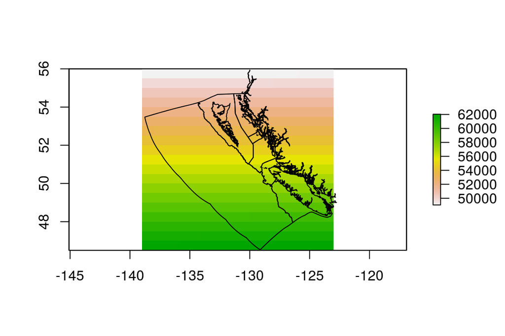

# 4 Load data

Read in the data, filter it between landings and discards. The data differentiates the catch into four categories of catch rate:

1. SSF_CR (small scale fisheries catch rate)
2. LSF_CR (Large scale fisheries catch rate)
3. IUU_CR (illegal, unregulated and unreported)
4. Discards_CR (discards)

The first three are aggregated by cell to represent total landings per cell. The last categorie, Discards_CR, is separated and used to represent the total tons of discarded catch.

An important note is that the data is provided as a “Catch Rate” meaning tons/km2. Since our final layer has a resolution of 1km<sup>2</sup>, we don’t need to multiply these catch rates by the total ocean area.

## 4.1 Five year means

Mean catch per cell is calculated over a rolling window of 5 years to account for interannual variability.

## 4.2 Reference Point

# 5 Results

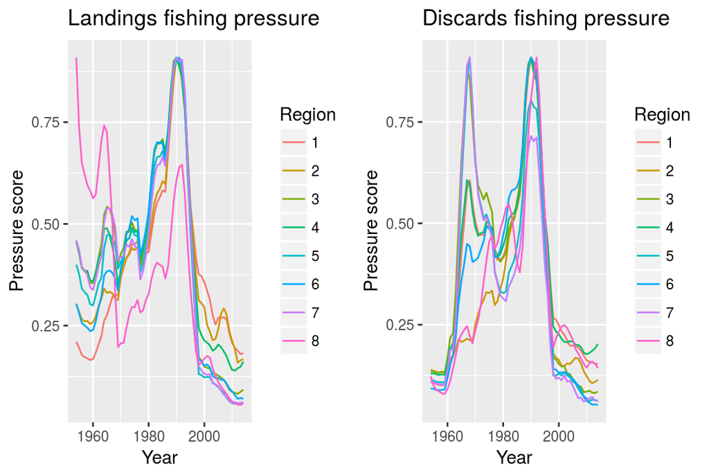

# 6 Citation information

Watson, R. A. (2017). A database of global marine commercial, small-scale, illegal and unreported fisheries catch 1950–2014. *Scientific Data*, 4.

# 7 Provenance

- *Run ID: 2 (a372662); run tag: “standard run”*
- *Run elapsed time: 188.941 seconds; run memory usage: 9544.3 MB*
- *System info:*
  - *System: Linux, Release: 4.4.0-57-generic. Machine: x86_64. User: ohara.*
  - *R version: R version 3.4.2 (2017-09-28), Platform: x86_64-pc-linux-gnu, Running under: Ubuntu 14.04.5 LTS.*
  - *Attached base packages: parallel, stats, graphics, grDevices, utils, datasets, methods, base*
  - *Other attached packages: bindrcpp_0.2, provRmd_0.1.1, stringr_1.2.0, RColorBrewer_1.1-2, sf_0.5-5, seaaroundus_1.0.1.9157, doParallel_1.0.10, iterators_1.0.8, foreach_1.4.3, raster_2.5-8, sp_1.2-5, dplyr_0.7.2, purrr_0.2.3, readr_1.1.0, tidyr_0.7.0, tibble_1.3.4, ggplot2_2.2.1.9000, tidyverse_1.1.1*

[figure not shown]

[output not shown]

[output cut: 120 more lines]